# Statistical Inference On General Social Survey (GSS) Dataset

Muhammad Shoaib Sarwar

## Setup

### Load Packages

```r
library(ggplot2)
library(dplyr)
library(statsr)
library(gmodels)
library(scales)
library(sqldf)
```

### Load Data

```r
load("gss.Rdata")
```

## Part 1: Data

```r
sqldf("select min(year) as start_year, max(year) as final_year
      from gss")
```

```
##   start_year final_year
## 1       1972       2012
```

```r
dim(gss)
```

```
## [1] 57061   114
```

The GSS data was collected from 1972 to 2012. There are total 57061 observations and variables are 114. Specific questions (such as national spending priorities, marijuana use, crime and punishment, race relations, quality of life, and confidence in institutions) were asked to the respondents. This implies that there can be missing values since every question is not applicable to each respondent.

## Part 2: Research Question (RQ)

**RQ:** Suicide opinion disparity exists between genders who have been unemployed in the last ten years from 1972 to 2012.

With the rise of feminism, it would be interesting to analyze whether opinions of females regarding suicide have changed over the years. And, is there similarity among males as well. For this purpose, I compare the proportions of men and women, and draw statistical inferences.

The variables used in this analysis are:

1. **suicide4:** A categorical variable indicating whether a person is tired of living and ready to die or not.

```r
sqldf("select suicide4, count(*) as total_count_of_suicide4_in_gss
      from gss
      group by suicide4")
```

```
##   suicide4 total_count_of_suicide4_in_gss
## 1     <NA>                          27853
## 2       No                          24629
## 3      Yes                           4579
```

2. **sex:** A categorical variable indicating the gender of the respondent.

```r
sqldf("select sex, count(*) as total_count_of_sex_in_gss
      from gss
      group by sex")
```

```
##      sex total_count_of_sex_in_gss
## 1 Female                     31915
## 2   Male                     25146
```

3. **unemp:** A categorical variable referring to unemployment of a person in the last ten years.

```r
sqldf("select unemp, count(*) as total_count_of_unemp_in_gss
      from gss
      group by unemp")
```

```
##   unemp total_count_of_unemp_in_gss
## 1  <NA>                       21554
## 2    No                       24517
## 3   Yes                       10990
```

4. **year:** From 1972 to 2012.

```r
sqldf("select year, count(*) as total_count_of_year_in_gss
      from gss
      group by year")
```

```
##    year total_count_of_year_in_gss
## 1  1972                       1613
## 2  1973                       1504
## 3  1974                       1484
## 4  1975                       1490
## 5  1976                       1499
## 6  1977                       1530
## 7  1978                       1532
## 8  1980                       1468
## 9  1982                       1860
## 10 1983                       1599
## 11 1984                       1473
## 12 1985                       1534
## 13 1986                       1470
## 14 1987                       1819
## 15 1988                       1481
## 16 1989                       1537
## 17 1990                       1372
## 18 1991                       1517
## 19 1993                       1606
## 20 1994                       2992
## 21 1996                       2904
## 22 1998                       2832
## 23 2000                       2817
## 24 2002                       2765
## 25 2004                       2812
## 26 2006                       4510
## 27 2008                       2023
## 28 2010                       2044
## 29 2012                       1974
```

Count aggregations on the above four variables shows that suicide4 and unemp have null values that needs to be fixed. The variable sex have two distinct values i.e. male and females, this is not the case in real life indicating a case of biasness against other genders.

```r
gss_suicide <- sqldf("select sex, year, suicide4
                     from gss
                     where (suicide4 is not null and unemp is not null) and unemp = 'Yes'")

dim(gss_suicide)
```

```
## [1] 5114    3
```

## Part 3: Exploratory Data Analysis

First of all, checking distribution of suicidal thoughts over the years of people who were unemployed.

```r
sqldf("select year, count(suicide4)
      from gss_suicide
      group by year")
```

```
##    year count(suicide4)
## 1  1977             428
## 2  1978             443
## 3  1983             523
## 4  1986             438
## 5  1988             148
## 6  1989             146
## 7  1990             129
## 8  1991             145
## 9  1993             177
## 10 1994             307
## 11 1996             314
## 12 1998             291
## 13 2000             295
## 14 2002             136
## 15 2004             153
## 16 2006             302
## 17 2008             228
## 18 2010             281
## 19 2012             230
```

Year 1983 had most observations with people having suicidal thoughts whereas 1990 is the year with least observations of people who were unemployed and had suicidal thoughts.

Now generating mosaic plot between genders and their suicidal thoughts.

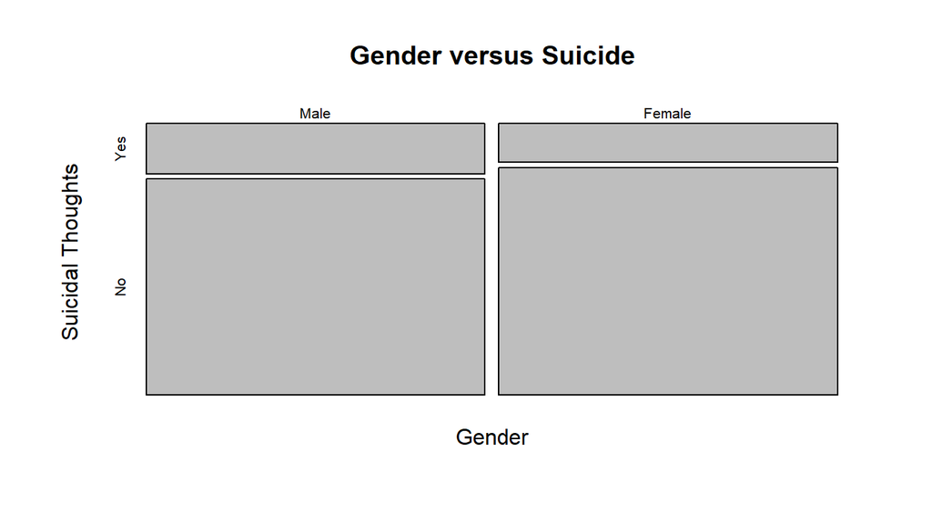

```r
mosaicplot(prop.table(table(gss_suicide$sex,gss_suicide$suicide),1),main = 'Gender versus Suicide',
           xlab = 'Gender',ylab = 'Suicidal Thoughts')
```

In the above plot, it can be seen that men have greater proportion of suicidal thoughts as compared to their counter-parts.

```r
gss_suicide_prop <- gss_suicide %>%
  group_by(sex,year) %>%
  summarise(prop = sum(suicide4 == "Yes")/n())
```

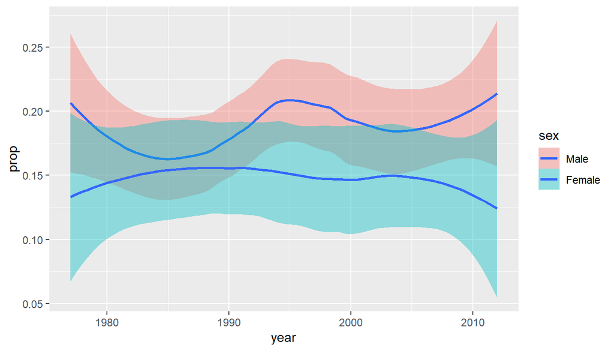

```r
ggplot(data=gss_suicide_prop, aes(x=year,y=prop)) + geom_smooth(aes(fill=sex))
```

The loess regression curves for the people who are tired of living and ready to die proportion in men and women is given in the above figure.

The following observations can be made:

- The peak for men occurred at around 1994 and women at around 1988.
- The proportion for men is higher as compared to women.
- The spread of proportion is wider for women.

## Part 4: Inference

**Null Hypothesis:** The mean difference in proportions of suicidal men and women is zero.

**Alternate Hypothesis:** The mean difference in proportions of suicidal men and women is greater than zero.

One side z-test is performed in-order to test the hypothesis.

First, finding out the pooled proportion as follows:

```r
gss_suicide %>%
  summarise(p_pool = sum(suicide4=="Yes")/n(),
            n_1 = sum(sex == "Female"),
            n_2 = sum(sex == "Male"),
            n_1_success = p_pool*n_1,
            n_1_fails = (1-p_pool)*n_1,
            n_2_success = p_pool*n_2,
            n_2_fails = (1-p_pool)*n_2,
            SE = sqrt((p_pool*(1 - p_pool)/n_1) + (p_pool*(1 - p_pool)/n_2)))
```

```
##      p_pool  n_1  n_2 n_1_success n_1_fails n_2_success n_2_fails         SE
## 1 0.1669926 2703 2411    451.3809  2251.619    402.6191  2008.381 0.01044797
```

From the above data, the minimum expected counts criterion of 10 is met for each cell in our 2x2 matrix. The distribution of the sample proportion will be nearly normal, centered at the true population mean.

```r
inference(y = suicide4, x = sex, data = gss_suicide, statistic = "proportion", type = "ht", null = 0, success="Yes", alternative ="greater", method = "theoretical")
```

```
## Response variable: categorical (2 levels, success: Yes)
## Explanatory variable: categorical (2 levels)
## n_Male = 2411, p_hat_Male = 0.1895
## n_Female = 2703, p_hat_Female = 0.1469
## H0: p_Male =  p_Female
## HA: p_Male > p_Female
## z = 4.0844
## p_value = < 0.0001
```

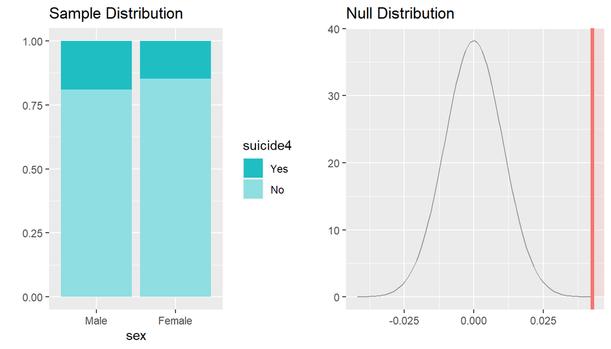

From above, it can be seen that the null hypothesis since difference in proportions is 4.0844 standard deviations away from the mean and p-value is less than 0.0001. Hence, it can be easily said that the mean difference in proportions of suicidal men and women is greater than zero.